# Pak Choi Diversity Analyses

```r
#season 2022-2023
pk_NMDS <- metaMDS(counts_wide_202223,trymax=200)
```

```
## Square root transformation
## Wisconsin double standardization
## *** Best solution repeated 1 times
```

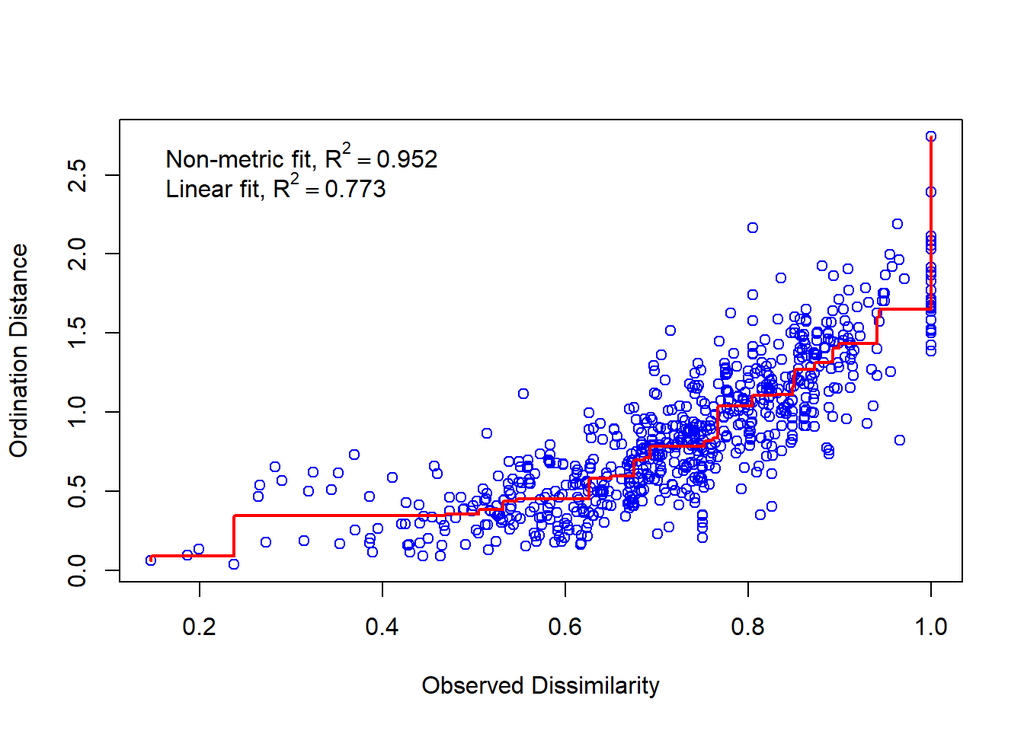

```r
stressplot(pk_NMDS)
```

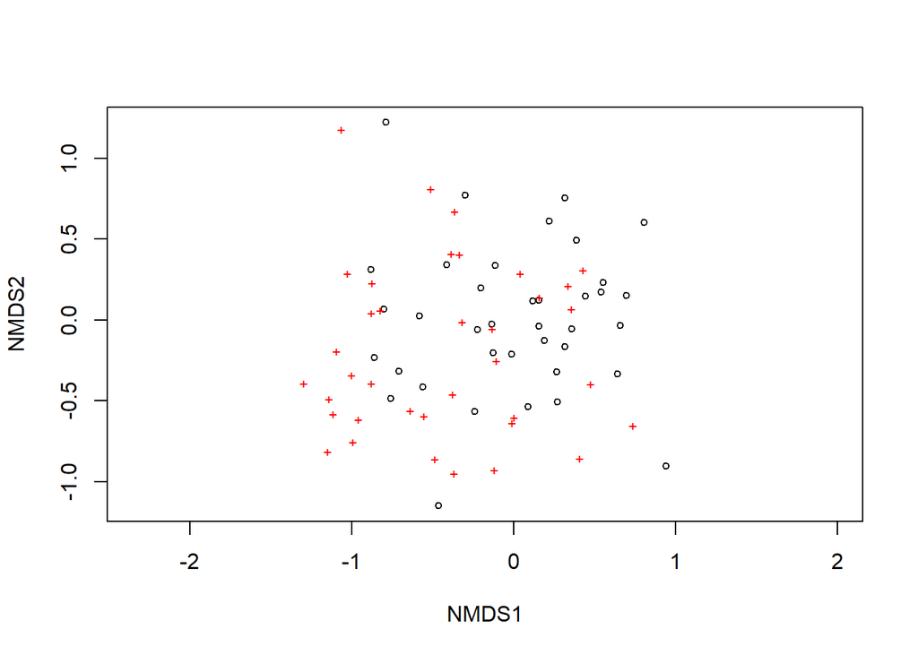

```r
plot(pk_NMDS)
```

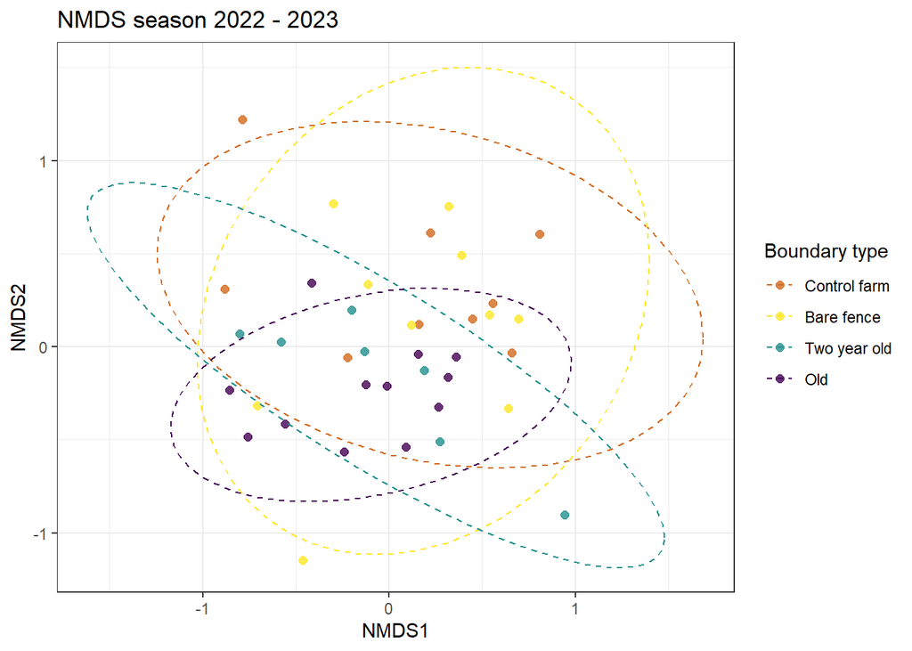

```r
plot_df <- scores(pk_NMDS, display = "sites") %>%
  as.data.frame() %>%
  rownames_to_column("site") %>%
  left_join(meta_data, by = c("site" = "unique_sample"))

plot_df$Boundary_descriptor <- factor(plot_df$Boundary_descriptor,levels=c('Control farm','Bare fence','One year old','Two year old','Three year old','Old'),ordered = T)

col_bound2<-c("chocolate", "#FDE725FF", "#21908CFF", "#440154FF")

plot_nmds <- ggplot(plot_df, aes(x = NMDS1, y = NMDS2, color = Boundary_descriptor)) +
  geom_point(size = 2, alpha = 0.8) +
  stat_ellipse(linetype = 2, linewidth = 0.5) +
  theme_bw()+
    scale_colour_manual(values=col_bound2)+
  labs(title = "NMDS season 2022 - 2023",
       colour = "Boundary type")
plot_nmds
```

```r
#season 2023-2024
pk_NMDS <- metaMDS(counts_wide_202324,trymax=200)
```

```
## Square root transformation
## Wisconsin double standardization
## *** Best solution repeated 1 times
```

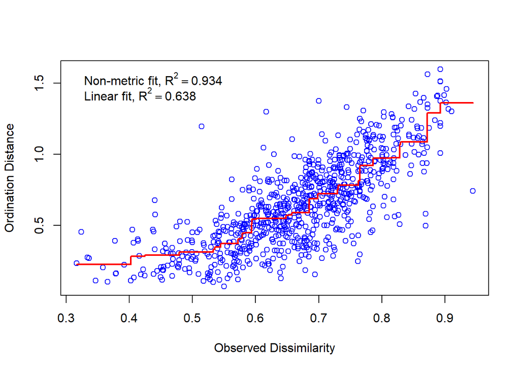

```r
stressplot(pk_NMDS)
```

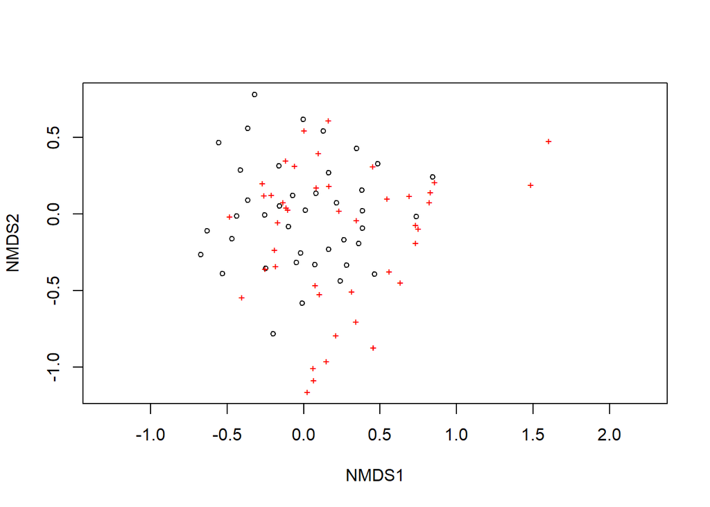

```r
plot(pk_NMDS)
```

```
## Too few points to calculate an ellipse
## Too few points to calculate an ellipse
```

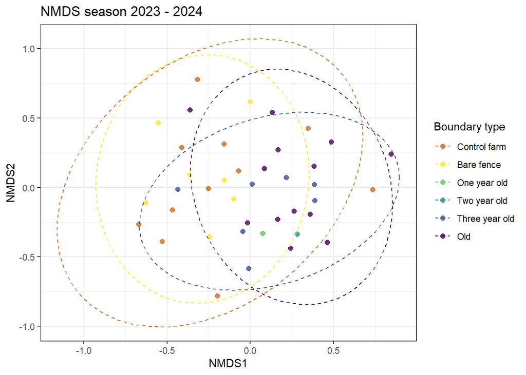

```r
plot_df <- scores(pk_NMDS, display = "sites") %>%
  as.data.frame() %>%
  rownames_to_column("site") %>%
  left_join(meta_data, by = c("site" = "unique_sample"))

plot_df$Boundary_descriptor <- factor(plot_df$Boundary_descriptor,levels=c('Control farm','Bare fence','One year old','Two year old','Three year old','Old'),ordered = T)

plot_nmds <- ggplot(plot_df, aes(x = NMDS1, y = NMDS2, color = Boundary_descriptor)) +
  geom_point(size = 2, alpha = 0.8) +
  stat_ellipse(linetype = 2, linewidth = 0.5) +
  theme_bw()+
    scale_colour_manual(values=col_bound)+
  labs(title = "NMDS season 2023 - 2024",
       colour = "Boundary type")
plot_nmds
```

## RDA

An alternative to adonis and MDs would be a rda (constrained PCA) and using th emodel. This is better I think. But again it loses everything is I add site and date in to the model conditions and Im suspect that is more to do with the over stratificaiton of the data with them in.

```r
counts_wide.Hellinger <- disttransform(counts_wide, method='hellinger')
#add conditions here:
Ordination.model2 <- rda(counts_wide.Hellinger ~ Boundary_descriptorf +  offset(log(`Flower count`)) + Condition(Season), data=meta_data_bior, scaling="species")
summary(Ordination.model2)
```

```
##
## Call:
## rda(formula = counts_wide.Hellinger ~ Boundary_descriptorf +      offset(log(`Flower count`)) + Condition(Season), data = meta_data_bior,      scaling = "species")
##
## Partitioning of variance:
##               Inertia Proportion
## Total         0.43680    1.00000
## Conditioned   0.03320    0.07600
## Constrained   0.03015    0.06902
## Unconstrained 0.37345    0.85498
##
## Eigenvalues, and their contribution to the variance
## after removing the contribution of conditiniong variables
##
## Importance of components:
##                          RDA1     RDA2     RDA3     RDA4      RDA5    PC1
## Eigenvalue            0.02181 0.003690 0.002355 0.001503 0.0007903 0.1011
## Proportion Explained  0.05404 0.009142 0.005835 0.003723 0.0019580 0.2505
## Cumulative Proportion 0.05404 0.063178 0.069013 0.072736 0.0746942 0.3251
##                          PC2     PC3     PC4     PC5     PC6     PC7     PC8
## Eigenvalue            0.0506 0.04294 0.02979 0.02286 0.01598 0.01553 0.01319
## Proportion Explained  0.1254 0.10638 0.07380 0.05665 0.03959 0.03849 0.03268
## Cumulative Proportion 0.4505 0.55691 0.63071 0.68736 0.72695 0.76543 0.79812
##                           PC9    PC10     PC11     PC12     PC13     PC14
## Eigenvalue            0.01267 0.01064 0.008508 0.006453 0.005799 0.005009
## Proportion Explained  0.03139 0.02637 0.021079 0.015988 0.014369 0.012410
## Cumulative Proportion 0.82951 0.85588 0.876960 0.892947 0.907316 0.919727
##                           PC15     PC16     PC17     PC18     PC19     PC20
## Eigenvalue            0.003960 0.003065 0.002871 0.002347 0.002299 0.002051
## Proportion Explained  0.009812 0.007594 0.007113 0.005814 0.005697 0.005081
## Cumulative Proportion 0.929539 0.937133 0.944246 0.950060 0.955757 0.960838
##                           PC21     PC22     PC23     PC24     PC25      PC26
## Eigenvalue            0.001744 0.001486 0.001415 0.001339 0.001192 0.0008905
## Proportion Explained  0.004322 0.003682 0.003507 0.003318 0.002953 0.0022064
## Cumulative Proportion 0.965160 0.968842 0.972349 0.975667 0.978620 0.9808261
##                            PC27     PC28      PC29      PC30     PC31      PC32
## Eigenvalue            0.0008606 0.000767 0.0007033 0.0006025 0.000578 0.0005253
## Proportion Explained  0.0021323 0.001900 0.0017424 0.0014929 0.001432 0.0013015
## Cumulative Proportion 0.9829584 0.984859 0.9866013 0.9880942 0.989526 0.9908279
##                            PC33      PC34      PC35      PC36      PC37
## Eigenvalue            0.0004712 0.0004339 0.0003629 0.0003375 0.0003038
## Proportion Explained  0.0011675 0.0010752 0.0008992 0.0008363 0.0007527
## Cumulative Proportion 0.9919954 0.9930706 0.9939698 0.9948061 0.9955587
##                            PC38      PC39      PC40      PC41      PC42
## Eigenvalue            0.0002593 0.0002314 0.0001951 0.0001881 0.0001743
## Proportion Explained  0.0006424 0.0005734 0.0004835 0.0004662 0.0004317
## Cumulative Proportion 0.9962012 0.9967746 0.9972581 0.9977242 0.9981560
##                            PC43     PC44      PC45      PC46      PC47
## Eigenvalue            0.0001551 0.000140 0.0001230 8.427e-05 6.842e-05
## Proportion Explained  0.0003844 0.000347 0.0003048 2.088e-04 1.695e-04
## Cumulative Proportion 0.9985404 0.998887 0.9991922 9.994e-01 9.996e-01
##                            PC48      PC49      PC50      PC51
## Eigenvalue            6.441e-05 5.858e-05 3.329e-05 1.706e-05
## Proportion Explained  1.596e-04 1.452e-04 8.248e-05 4.226e-05
## Cumulative Proportion 9.997e-01 9.999e-01 1.000e+00 1.000e+00
##
## Accumulated constrained eigenvalues
## Importance of components:
##                          RDA1    RDA2     RDA3     RDA4      RDA5
## Eigenvalue            0.02181 0.00369 0.002355 0.001503 0.0007903
## Proportion Explained  0.72343 0.12239 0.078121 0.049845 0.0262137
## Cumulative Proportion 0.72343 0.84582 0.923942 0.973786 1.0000000
```

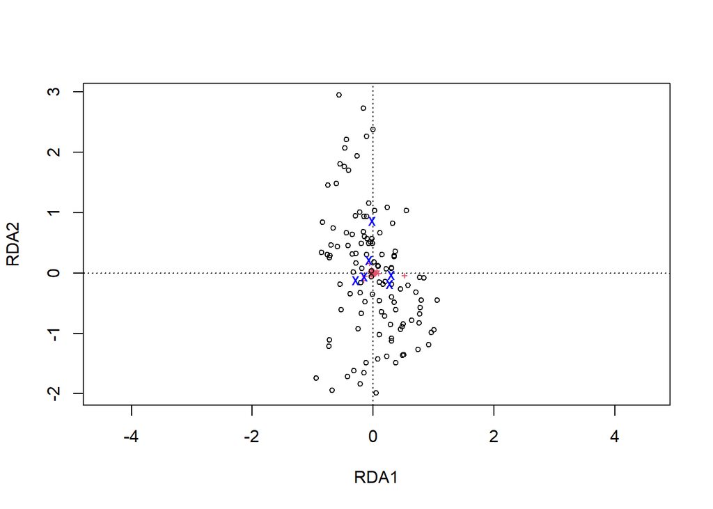

```r
plot2 <- ordiplot(Ordination.model2, choices=c(1,2))
```

```r
sites.long2 <- sites.long(plot2, env.data=meta_data_bior)
head(sites.long2)
```

```
##                                                 unique_sample
## Control farm Ahuriri 2021/22     Control farm Ahuriri 2021/22
## One year old Ahuriri 2021/22     One year old Ahuriri 2021/22
## Control farm Ahuriri 2022/23     Control farm Ahuriri 2022/23
## Two year old Ahuriri 2022/23     Two year old Ahuriri 2022/23
## Control farm Ahuriri 2023/24     Control farm Ahuriri 2023/24
## Three year old Ahuriri 2023/24 Three year old Ahuriri 2023/24
##                                Boundary_descriptor  Season Farm_name Farm.type
## Control farm Ahuriri 2021/22          Control farm 2021/22   Ahuriri    Arable
## One year old Ahuriri 2021/22          One year old 2021/22   Ahuriri    Arable
## Control farm Ahuriri 2022/23          Control farm 2022/23   Ahuriri    Arable
## Two year old Ahuriri 2022/23          Two year old 2022/23   Ahuriri    Arable
## Control farm Ahuriri 2023/24          Control farm 2023/24   Ahuriri    Arable
## Three year old Ahuriri 2023/24      Three year old 2023/24   Ahuriri    Arable
##                                Flower.count            Site       Date
## Control farm Ahuriri 2021/22            271 Ahuriri_control 15_03_2022
## One year old Ahuriri 2021/22            233  Ahuriri_plant1 15_03_2022
## Control farm Ahuriri 2022/23            269 Ahuriri_control 09_02_2023
## Two year old Ahuriri 2022/23            210  Ahuriri_plant1 09_02_2023
## Control farm Ahuriri 2023/24            178 Ahuriri_control 15_02_2024
## Three year old Ahuriri 2023/24          171  Ahuriri_plant1 15_02_2024
##                                Boundary_descriptorf Farmtypef      axis1
## Control farm Ahuriri 2021/22           Control farm    Arable -0.1524684
## One year old Ahuriri 2021/22           One year old    Arable -0.4429922
## Control farm Ahuriri 2022/23           Control farm    Arable -0.5926498
## Two year old Ahuriri 2022/23           Two year old    Arable  1.0606479
## Control farm Ahuriri 2023/24           Control farm    Arable -0.4094835
## Three year old Ahuriri 2023/24       Three year old    Arable  0.1620965
##                                     axis2                         labels
## Control farm Ahuriri 2021/22    0.9368345   Control farm Ahuriri 2021/22
## One year old Ahuriri 2021/22    2.2084166   One year old Ahuriri 2021/22
## Control farm Ahuriri 2022/23    0.4377732   Control farm Ahuriri 2022/23
## Two year old Ahuriri 2022/23   -0.4534239   Two year old Ahuriri 2022/23
## Control farm Ahuriri 2023/24    1.6972358   Control farm Ahuriri 2023/24
## Three year old Ahuriri 2023/24 -0.1842331 Three year old Ahuriri 2023/24
```

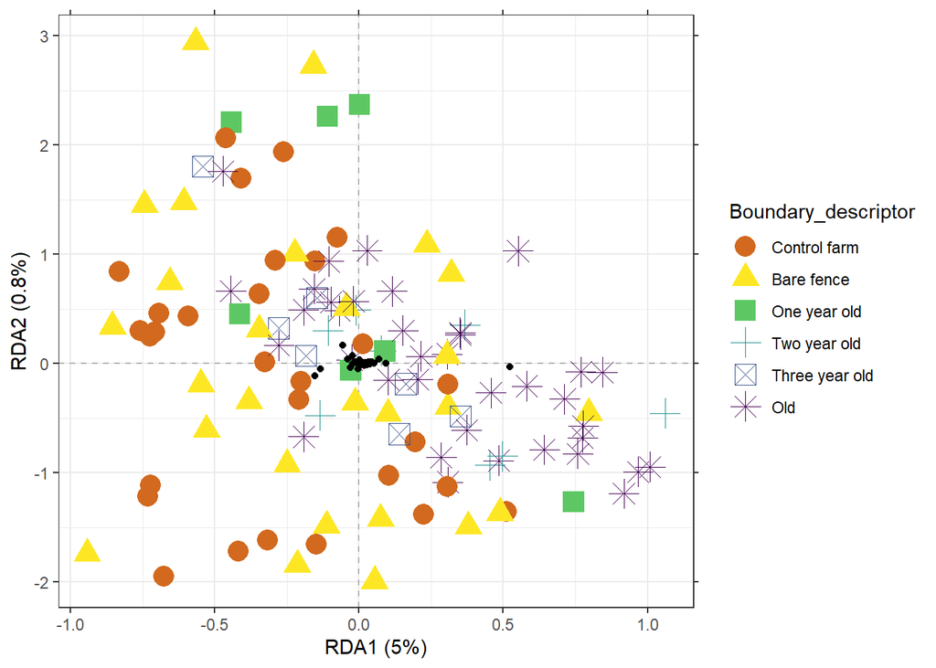

```r
species.long2 <- species.long(plot2)
axis.long2 <- axis.long(Ordination.model2, choices=c(1, 2))
sites.long2$Boundary_descriptor <- factor(sites.long2$Boundary_descriptor,levels=c('Control farm','Bare fence','One year old','Two year old','Three year old','Old'),ordered = T)
plotgg2 <- ggplot() +
    geom_vline(xintercept = c(0), color = "grey70", linetype = 2) +
    geom_hline(yintercept = c(0), color = "grey70", linetype = 2) +
    xlab(axis.long2[1, "label"]) +
    ylab(axis.long2[2, "label"]) +
    scale_x_continuous(sec.axis = dup_axis(labels=NULL, name=NULL)) +
    scale_y_continuous(sec.axis = dup_axis(labels=NULL, name=NULL)) +
    geom_point(data=sites.long2,
               aes(x=axis1, y=axis2, colour=Boundary_descriptor, shape=Boundary_descriptor),
               size=5) +
      scale_colour_manual(values=col_bound)+
    geom_point(data=species.long2,
               aes(x=axis1, y=axis2)) +
  theme_bw()
plotgg2
```

```r
spec.envfit <- envfit(plot2, env=counts_wide.Hellinger)
spec.data.envfit <- data.frame(r=spec.envfit$vectors$r, p=spec.envfit$vectors$pvals)
species.long2 <- species.long(plot2, spec.data=spec.data.envfit)
#species that explain 10% of variation
species.long3 <- species.long2[species.long2$r >= 0.1, ]
species.long3
```

```
##                             r     p       axis1       axis2              labels
## Honey.bee           0.1199020 0.002  0.06835130  0.04382431           Honey.bee
## Lasioglossum.bee    0.9415633 0.001  0.52239478 -0.03142651    Lasioglossum.bee
## Striped.flesh.fly   0.1109711 0.003 -0.13259518 -0.04601589   Striped.flesh.fly
## Drone.fly           0.4982587 0.001 -0.15212951 -0.11157940           Drone.fly
## NZ.orange.hover.fly 0.7632841 0.001 -0.05600311  0.16556643 NZ.orange.hover.fly
```

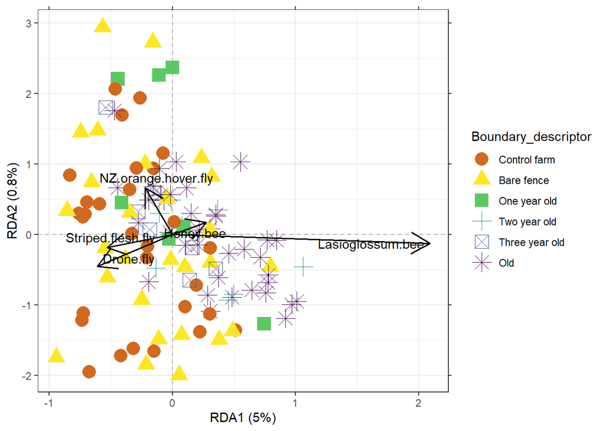

```r
plotgg2 <- ggplot() +
    geom_vline(xintercept = c(0), color = "grey70", linetype = 2) +
    geom_hline(yintercept = c(0), color = "grey70", linetype = 2) +
    xlab(axis.long2[1, "label"]) +
    ylab(axis.long2[2, "label"]) +
    scale_x_continuous(sec.axis = dup_axis(labels=NULL, name=NULL)) +
    scale_y_continuous(sec.axis = dup_axis(labels=NULL, name=NULL)) +
    geom_point(data=sites.long2,
               aes(x=axis1, y=axis2, colour=Boundary_descriptor, shape=Boundary_descriptor),
               size=5) +
   scale_colour_manual(values=col_bound)+
    geom_segment(data=species.long3,
                 aes(x=0, y=0, xend=axis1*4, yend=axis2*4),
                 colour="black", size=0.7, arrow=arrow()) +
    geom_text_repel(data=species.long3,
                    aes(x=axis1*4, y=axis2*4, label=labels),
                    colour="black") +
    theme_bw()

plotgg2
```

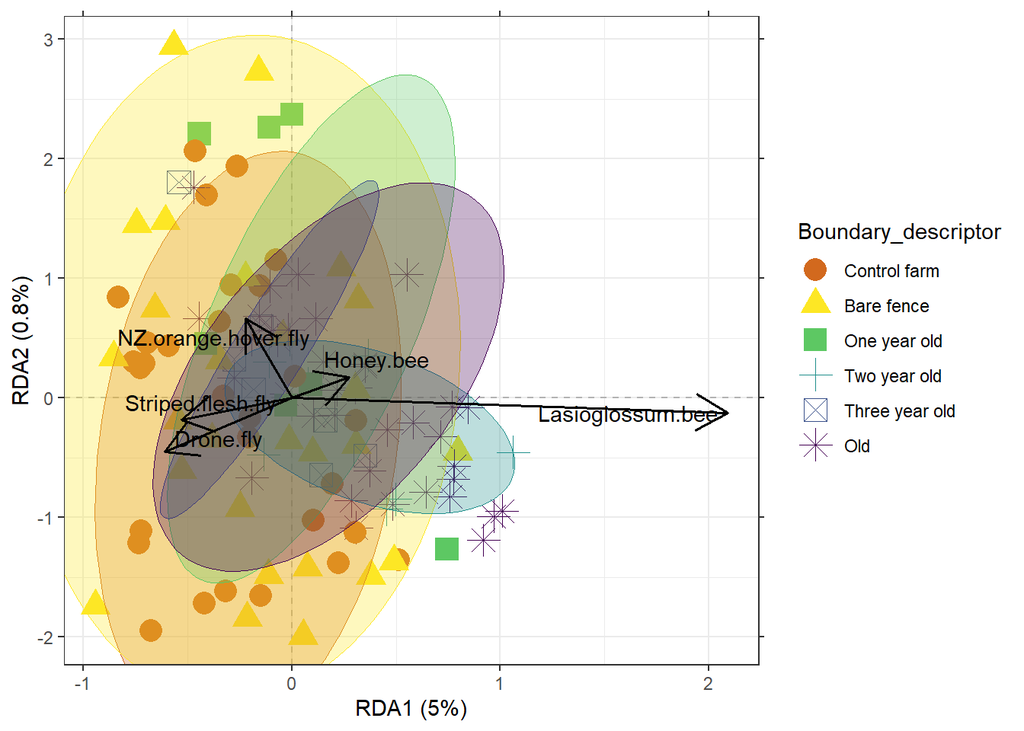

```r
plotgg2 <- ggplot() +
    geom_vline(xintercept = c(0), color = "grey70", linetype = 2) +
    geom_hline(yintercept = c(0), color = "grey70", linetype = 2) +
    xlab(axis.long2[1, "label"]) +
    ylab(axis.long2[2, "label"]) +
    scale_x_continuous(sec.axis = dup_axis(labels=NULL, name=NULL)) +
    scale_y_continuous(sec.axis = dup_axis(labels=NULL, name=NULL)) +
    geom_point(data=sites.long2,
               aes(x=axis1, y=axis2, colour=Boundary_descriptor, shape=Boundary_descriptor),
               size=5) +
  geom_mark_ellipse(data=sites.long2,
                      aes(x=axis1, y=axis2, colour=Boundary_descriptor,
                          fill=after_scale(alpha(colour, 0.2))),
                      expand=0, size=0.2, show.legend=FALSE) +
    scale_colour_manual(values=col_bound)+
    geom_segment(data=species.long3,
                 aes(x=0, y=0, xend=axis1*4, yend=axis2*4),
                 colour="black", size=0.7, arrow=arrow()) +
    geom_text_repel(data=species.long3,
                    aes(x=axis1*4, y=axis2*4, label=labels),
                    colour="black") +
    theme_bw()

plotgg2
```

```r
#dont think the eclipses help


#alternative would be capscale on bray distance
cap <- capscale(counts_wide ~ Boundary_descriptorf + offset(log(`Flower count`)) + Condition(Season), data = meta_data_bior, distance = "bray")
anova(cap, by = "terms")
```

```
## Permutation test for capscale under reduced model
## Terms added sequentially (first to last)
## Permutation: free
## Number of permutations: 999
##
## Model: capscale(formula = counts_wide ~ Boundary_descriptorf + offset(log(`Flower count`)) + Condition(Season), data = meta_data_bior, distance = "bray")
##                       Df SumOfSqs      F Pr(>F)
## Boundary_descriptorf   5   2.8582 2.0726  0.001 ***
## Residual             107  29.5118
## ---
## Signif. codes:  0 '***' 0.001 '**' 0.01 '*' 0.05 '.' 0.1 ' ' 1
```

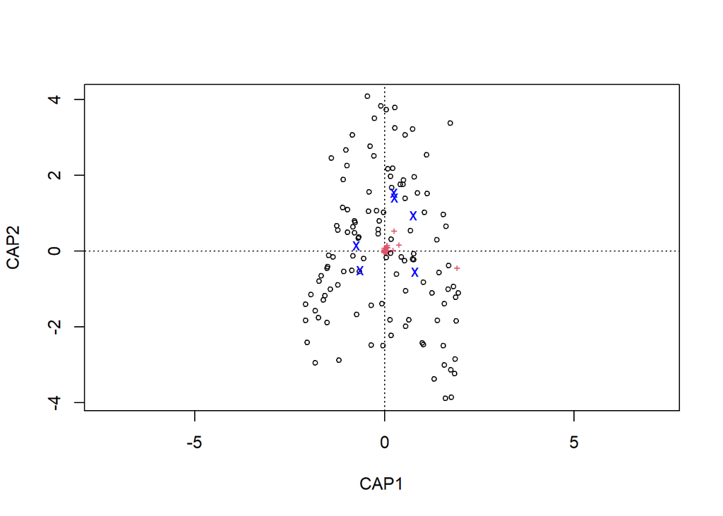

```r
plot(cap)
```

```r
#fortify(mod)
#mod$CCA$
site_scores <- scores(cap, display = "sites")
species_scores <- scores(cap, display = "species")
centroids <- scores(cap, display = "cn")


df_sites <- as.data.frame(site_scores)
df_sites$unique_sample <- rownames(df_sites)
capscale_df <- left_join(df_sites,meta_data)
```

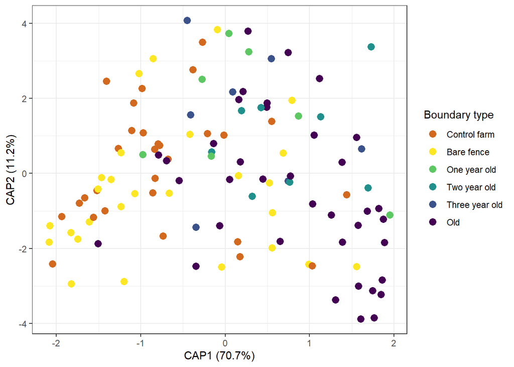

```r
capscale_df$Boundary_descriptor <- factor(capscale_df$Boundary_descriptor,levels=c('Control farm','Bare fence','One year old','Two year old','Three year old','Old'),ordered = T)

eig_vals <- cap$CCA$eig
prop_var <- eig_vals / sum(eig_vals)

xlab <- paste0("CAP1 (", round(prop_var[1] * 100, 1), "%)")
ylab <- paste0("CAP2 (", round(prop_var[2] * 100, 1), "%)")

ggplot(capscale_df, aes(x = CAP1, y = CAP2, color = Boundary_descriptor)) +
  geom_point(size = 3) +
 scale_colour_manual(values=col_bound)+
  labs(x = xlab, y = ylab, color='Boundary type') +
  theme_bw()
```

```r
#but I think its much of a muchness with rda
```

## iNEXT

iNEXT (iNterpolation and EXTrapolation) is an R package, available in CRAN and Github, for rarefaction and extrapolation of species diversity (Hill numbers). It’s a useful package to use if you want to make any predictions about sampling size or diversity.

### Hill numbers

Hill numbers are a set of diversity indices used in ecology and biodiversity assessments to quantify the richness and evenness of species in a given community. These indices were developed by Michael Hill and are widely used to summarize various aspects of biodiversity. Hill numbers are particularly useful because they provide a way to focus on different facets of diversity, depending on the specific questions or goals of a study. For a thorough introduction to Hill numbers check out: Alberdi & Gilbert

There are several Hill numbers, but they all share a common formula that relies on an exponent, denoted as “q.” The choice of the exponent determines which aspect of diversity is emphasized:

- Richness (q = 0): Hill number with q = 0 is also known as the “species richness” or “taxonomic distinctness” index. It simply counts the number of unique species in a community without considering their abundances. This index is valuable when you want to emphasize the presence or absence of species but not their relative abundance.
- Exponential Shannon entropy (q = 1): This index corresponds to the Shannon-Wiener diversity index (commonly referred to as Shannon entropy) when q is set to 1. It considers both the richness and the evenness of species abundances. It is often used when you want to give equal importance to species richness and evenness.
- Inverse Simpson index (q = 2): The Inverse Simpson index corresponds to the Simpson diversity index when q is set to 2. This index emphasizes the dominance of the most abundant species in a community. It is often used when you want to give more weight to the presence of dominant species.
- Higher Hill numbers (q > 2): These Hill numbers give increasing weight to the most abundant species, placing more emphasis on the dominant species in the community. The larger the value of q, the more sensitive the index becomes to the presence of dominant species.

Hill numbers offer a flexible framework for assessing biodiversity because they allow you to choose the appropriate value of q based on the specific ecological question or management objective you are addressing. For example:

- If you want to measure the overall diversity of a community while considering both species richness and evenness, you might use q = 1.
- If you are concerned about the impact of a few highly dominant species in an ecosystem, you might use q = 2 or a higher value to focus on those dominant species.

#iNEXT package iNEXT is a neat package that can calculate Hill numbers, enabling us to investigate alpha diversity accumulation curves (similar to species accumulation curves). These graphs can help us determine if sufficient sampling was conducted at each site, based on the plateauing of the curves, similar to the rarefaction curves. But iNEXT.3D goes beyond rarefraction and extrapolates alpha diversity numbers beyond the number of samples collected (default is double sample number). Its written by Anne Chao and you can find her papers here: https://sites.google.com/view/chao-lab-website/home

### Running iNEXT

```r
#innext uses a weird list of lists, this is a annoying format to get into
#im using raw incident data as the input (thus it is made binary at one point in the code)

#generate a list of the unique sample locations
categories <- unique(data$Boundary_descriptor)
categories
```

```
## [1] "Control farm"   "One year old"   "Two year old"   "Three year old"
## [5] "Old"            "Bare fence"
```

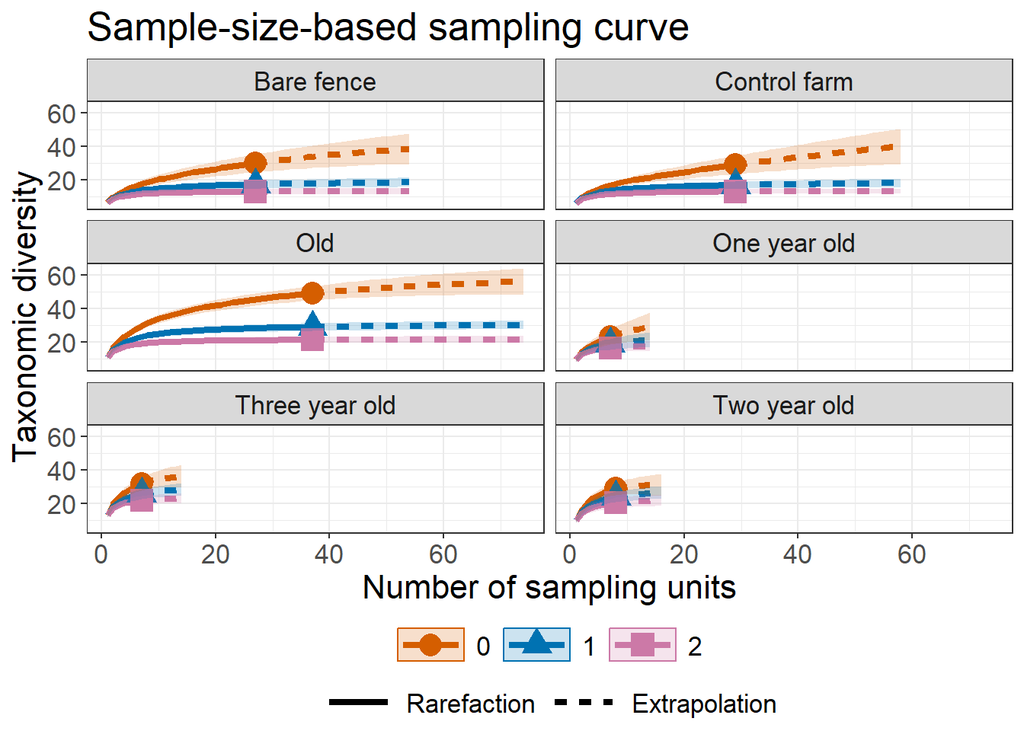

```r
#create empty list
split_list <- list()
#fill empty list with a presence absence OTU from each location

data<-data %>% mutate(unique_ob=paste(Boundary_descriptor,Farm_name,Season))

for (category in categories) {
  subset_data <- data %>% filter(Boundary_descriptor == category)
  test<-subset_data %>% ungroup() %>% dplyr::select(unique_ob,`New Inseck key name`,`Sum of Insects/100 flowers`)
  test   <- test %>%  spread(key = unique_ob, value = `Sum of Insects/100 flowers`)
  test<-test %>% remove_rownames %>% column_to_rownames(var="New Inseck key name")
  test<-test %>% mutate(across(everything(), ~ ifelse(. > 0, 1, 0)))
  split_list[[category]]<-as(test,'matrix')
}

matrix_list <- list(data = list())
for (category in categories) {
  otu_table <- as(split_list[[category]], "matrix")
  matrix_list[["data"]][[category]] <- otu_table
}

#here Im setting the endpoint as NULL which is double the input sample size (this is probably most robust)
out.raw <- iNEXT3D(data = matrix_list$data, diversity = 'TD', q = c(0, 1, 2), datatype = 'incidence_raw', nboot = 50,endpoint=NULL)

#there is various ways to look at these plots:
#within a sample
ggiNEXT3D(out.raw, type = 1, facet.var = 'Assemblage') + facet_wrap(~Assemblage, nrow = 3)
```

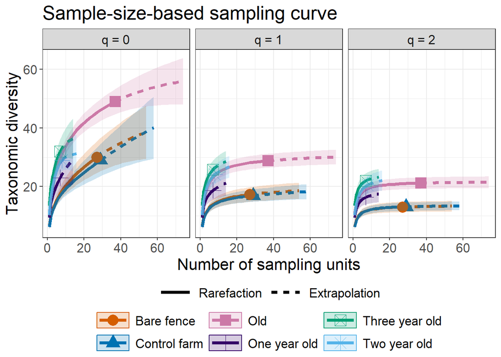

```r
#across samples
ggiNEXT3D(out.raw, type = 1, facet.var = "Order.q")
```

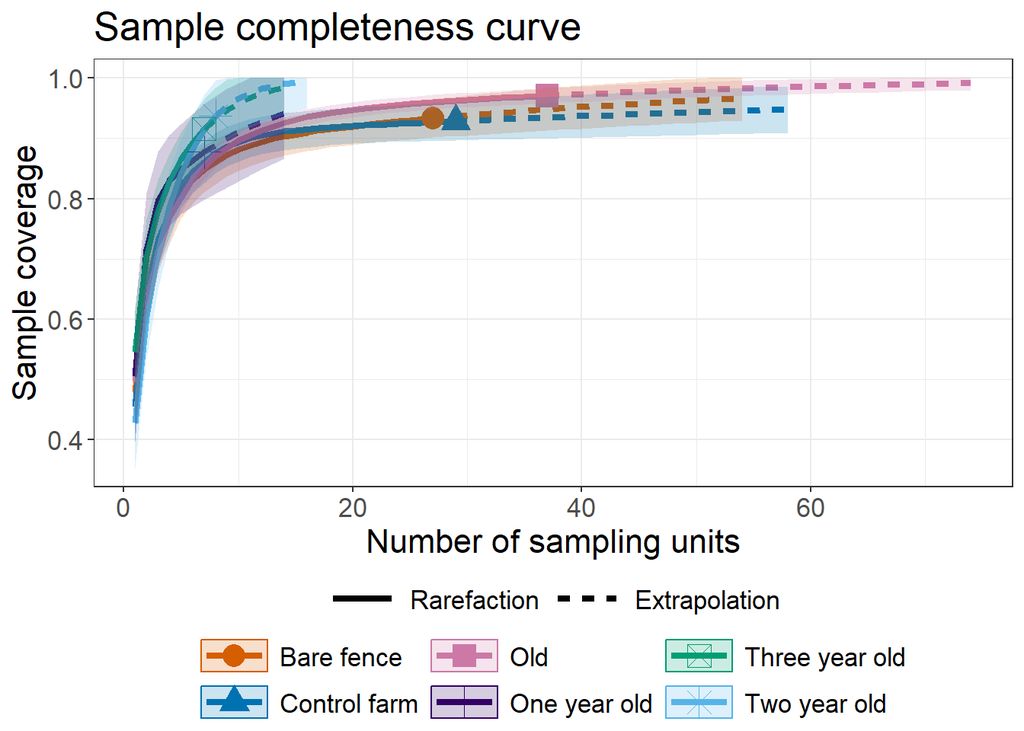

```r
#sample completeness
ggiNEXT3D(out.raw, type = 2, facet.var = "Order.q", color.var = "Assemblage")
```

```r
#using innext diversity estimates in a model
```

# Alternative plots for iNEXT

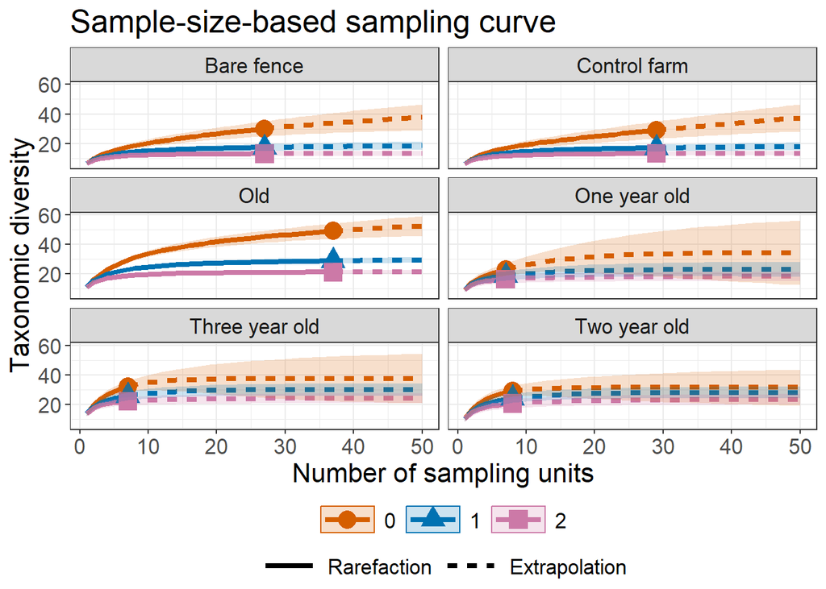

```r
out.raw <- iNEXT3D(data = matrix_list$data, diversity = 'TD', q = c(0, 1, 2), datatype = 'incidence_raw', nboot = 50,endpoint=50)

#there is various ways to look at these plots:
#within a sample
ggiNEXT3D(out.raw, type = 1, facet.var = 'Assemblage') + facet_wrap(~Assemblage, nrow = 3)
```

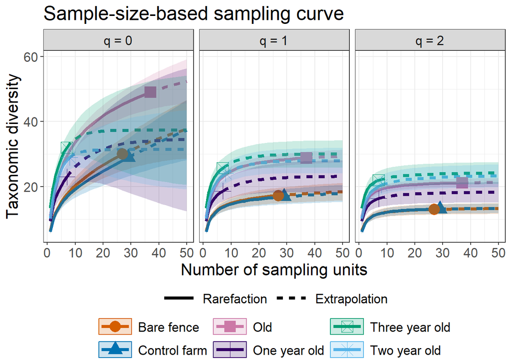

```r
#across samples
ggiNEXT3D(out.raw, type = 1, facet.var = "Order.q")
```

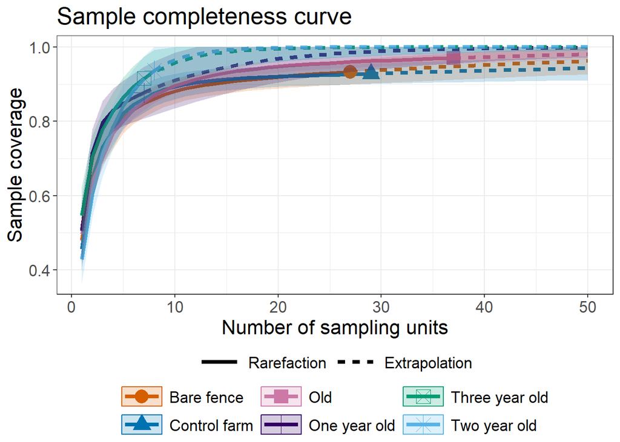

```r
#sample completeness
ggiNEXT3D(out.raw, type = 2, facet.var = "Order.q", color.var = "Assemblage")
```

## Just a base tests to show that there is significantly more counts by planting age

Just mucking around trying to think of ways to highlight the great raw counts in old, 3 years etc

```r
insect_counts<-rowSums(counts_wide)

insect_counts_df<-data.frame(insect_counts)
insect_counts_df <- rownames_to_column(insect_counts_df, var = "unique_sample")
insect_counts_df<-left_join(insect_counts_df,meta_data)
```

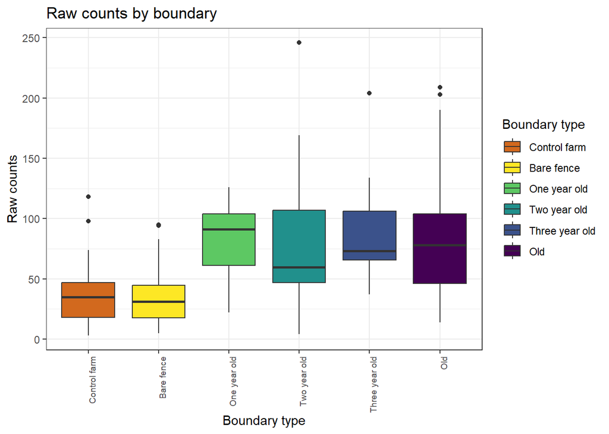

```r
insect_counts_df$Boundary_descriptor <- factor(insect_counts_df$Boundary_descriptor,levels=c('Control farm','Bare fence','One year old','Two year old','Three year old','Old'),ordered = T)
#split by season
plot_sppr <- ggplot(insect_counts_df, aes(x = Boundary_descriptor, y = insect_counts, fill = Boundary_descriptor)) +
  geom_boxplot() +
#  facet_wrap(~Season)+
  theme_bw()+
  scale_fill_manual(values=col_bound)+
  labs(x = "Boundary type",
       y = "Raw counts",
       title = "Raw counts by boundary",
       fill = "Boundary type")+
  theme(axis.text.x = element_text(angle = 90,size=7,hjust=1))

plot_sppr
```

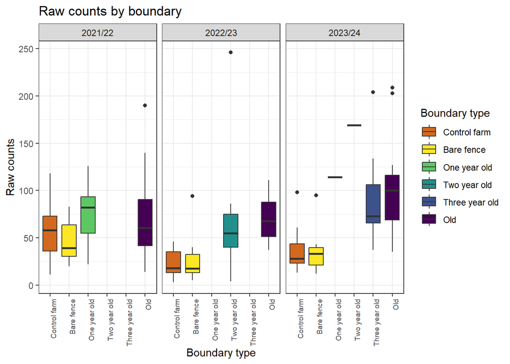

```r
#split by season
plot_sppr <- ggplot(insect_counts_df, aes(x = Boundary_descriptor, y = insect_counts, fill = Boundary_descriptor)) +
  geom_boxplot() +
  facet_wrap(~Season)+
  theme_bw()+
  scale_fill_manual(values=col_bound)+
  labs(x = "Boundary type",
       y = "Raw counts",
       title = "Raw counts by boundary",
       fill = "Boundary type")+
  theme(axis.text.x = element_text(angle = 90,size=7,hjust=1))

plot_sppr
```

```r
#issue with model convergence iwth glmmtmb with more nested models, current work around
m0<-lmer(insect_counts ~ Boundary_descriptor + offset(log(`Flower count`)) +(1|Season) , data = meta_data)
m1<-lmer(insect_counts ~ Boundary_descriptor + offset(log(`Flower count`)) +(1|Season) +(1|Site), data = meta_data)
m2<-lmer(insect_counts ~ Boundary_descriptor+Season + offset(log(`Flower count`)) +(1|Season)+ (1|Date), data = meta_data)
m3<-lmer(insect_counts ~ Boundary_descriptor+Season + offset(log(`Flower count`)) +(1|Season)+ (1|Date) + (1|Site), data = meta_data)
AIC(m0,m1)
```

```
##    df      AIC
## m0  8 1152.131
## m1  9 1153.841
```

```r
anova(m0,m1)
```

```
## refitting model(s) with ML (instead of REML)
```

```
## Data: meta_data
## Models:
## m0: insect_counts ~ Boundary_descriptor + offset(log(`Flower count`)) + (1 | Season)
## m1: insect_counts ~ Boundary_descriptor + offset(log(`Flower count`)) + (1 | Season) + (1 | Site)
##    npar    AIC    BIC  logLik -2*log(L) Chisq Df Pr(>Chisq)
## m0    8 1192.7 1214.7 -588.35    1176.7
## m1    9 1194.6 1219.3 -588.29    1176.6 0.104  1      0.747
```

```r
#model 2 and 3 failed to converge

#so no random effects beyond season
sppr_aov <-aov(insect_counts ~ Boundary_descriptor + Season + offset(log(`Flower count`)) , data = meta_data)
summary(sppr_aov)
```

```
##                      Df Sum Sq Mean Sq F value   Pr(>F)
## Boundary_descriptor   5  63463   12693   7.667 3.42e-06 ***
## Season                2  12532    6266   3.785   0.0258 *
## Residuals           107 177139    1656
## ---
## Signif. codes:  0 '***' 0.001 '**' 0.01 '*' 0.05 '.' 0.1 ' ' 1
```

```r
TukeyHSD(sppr_aov)
```

```
##   Tukey multiple comparisons of means
##     95% family-wise confidence level
##
## Fit: aov(formula = insect_counts ~ Boundary_descriptor + Season + offset(log(`Flower count`)), data = meta_data)
##
## $Boundary_descriptor
##                                  diff        lwr       upr     p adj
## Control farm-Bare fence      1.022724 -30.554882  32.60033 0.9999989
## Old-Bare fence              45.210932  15.324552  75.09731 0.0003768
## One year old-Bare fence     44.210300  -5.870889  94.29149 0.1159764
## Three year old-Bare fence   56.806263   6.725074 106.88745 0.0165615
## Two year old-Bare fence     50.423881   2.893290  97.95447 0.0308396
## Old-Control farm            44.188208  14.903683  73.47273 0.0003932
## One year old-Control farm   43.187575  -6.536796  92.91195 0.1273660
## Three year old-Control farm 55.783539   6.059167 105.50791 0.0184528
## Two year old-Control farm   49.401157   2.246680  96.55563 0.0343416
## One year old-Old            -1.000632 -49.668523  47.66726 0.9999999
## Three year old-Old          11.595331 -37.072560  60.26322 0.9825571
## Two year old-Old             5.212950 -40.826113  51.25201 0.9994784
## Three year old-One year old 12.595963 -50.518959  75.71088 0.9922068
## Two year old-One year old    6.213582 -54.897178  67.32434 0.9996917
## Two year old-Three year old -6.382381 -67.493141  54.72838 0.9996485
##
## $Season
##                       diff         lwr       upr     p adj
## 2022/23-2021/22 -17.341745 -39.6769617  4.993471 0.1599249
## 2023/24-2021/22   4.969548 -17.0884805 27.027577 0.8540606
## 2023/24-2022/23  22.311294   0.4045564 44.218031 0.0449068
```

```r
m0<-lmer(insect_counts ~ Boundary_descriptor + offset(log(`Flower count`)) +(1|Season) , data = meta_data)

emm2 <- emmeans(m0, ~ Boundary_descriptor,type = "response")
pairs(emm2,simple='each',  adjust = "tukey")
```

```
##  contrast                      estimate   SE  df t.ratio p.value
##  Bare fence - Control farm        0.414 10.9 107   0.038  1.0000
##  Bare fence - Old               -44.108 10.3 107  -4.267  0.0006
##  Bare fence - One year old      -39.160 18.0 109  -2.178  0.2567
##  Bare fence - Three year old    -47.939 18.7 108  -2.562  0.1158
##  Bare fence - Two year old      -58.609 17.2 109  -3.411  0.0114
##  Control farm - Old             -44.523 10.1 107  -4.410  0.0003
##  Control farm - One year old    -39.574 18.0 109  -2.201  0.2457
##  Control farm - Three year old  -48.353 18.2 109  -2.661  0.0918
##  Control farm - Two year old    -59.023 17.2 109  -3.434  0.0106
##  Old - One year old               4.948 17.6 109   0.281  0.9998
##  Old - Three year old            -3.830 17.9 109  -0.214  0.9999
##  Old - Two year old             -14.501 16.8 109  -0.864  0.9542
##  One year old - Three year old   -8.779 23.8 107  -0.369  0.9991
##  One year old - Two year old    -19.449 23.3 106  -0.835  0.9603
##  Three year old - Two year old  -10.670 23.3 106  -0.458  0.9974
##
## Degrees-of-freedom method: kenward-roger
## P value adjustment: tukey method for comparing a family of 6 estimates
```

```r
#running each as I think all comparisons is a bit over the top and probably repeating things
cld_rich <- multcomp::cld(emm2, Letters = letters, adjust = "tukey")
```

```
## Note: adjust = "tukey" was changed to "sidak"
## because "tukey" is only appropriate for one set of pairwise comparisons
```

```r
colnames(cld_rich)
```

```
## [1] "Boundary_descriptor" "emmean"              "SE"
## [4] "df"                  "lower.CL"            "upper.CL"
## [7] ".group"
```

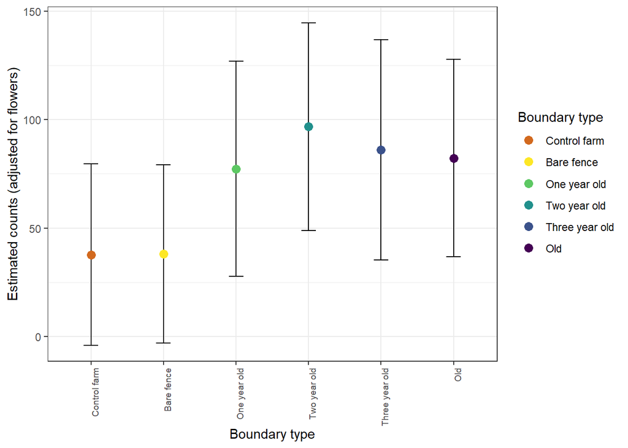

```r
cld_rich$Boundary_descriptor <- factor(cld_rich$Boundary_descriptor,levels=c('Control farm','Bare fence','One year old','Two year old','Three year old','Old'),ordered = T)

ggplot(cld_rich, aes(x = Boundary_descriptor, y = emmean)) +
  theme_bw()+
  geom_errorbar(aes(ymin = lower.CL, ymax = upper.CL), width = 0.2) +
  geom_point(size = 3,aes(colour=Boundary_descriptor)) +
  scale_colour_manual(values=col_bound)+
# not sure if groupings will make sense with facet wrap
#  geom_text(aes(label = .group, y = asymp.UCL + 0.2), vjust = 0, size = 5) +
  labs(y = "Estimated counts (adjusted for flowers)", x = "Boundary type", colour='Boundary type') +
  theme(axis.text.x = element_text(angle = 90,size=7,hjust=1))
```